# **Determining a Driver's Inebriation Status using Regression Analysis**

Joseph Penovich  
CMSC320: Introduction to Data Science - Summer 2023  
Due August 20th, 2023

1. Introduction  
   a. Background  
   b. Data
2. Part 1: Data Collection, Parsing, and Management
3. Part 2: Data Exploration and Analysis  
   a. Roads  
   b. Time Periods  
   c. Vehicle Make and Year  
   d. Intersection
4. Part 3: Regression Analysis and Prediction
5. Final Section  
   a. Discussion  
   b. Conclusion  
   c. Special Thanks

## Introduction

### Background

The United States has one of the highest rates of deaths caused by vehicles accidents involving alcohol, which is difficult to attribute to any one factor. Arguments can be made about factors including the US's car dependent infrastructure, it's culture and stigma surrounding drinking alcohol and taking substances, local state and county traffic legislation, and more. One thing that can be agreed upon is that there is absolutely no reason or justification for driving while under the influence. It can be difficult for police to determine whether a traffic incident involves alcohol or other substances without conducting sobriety tests on those involved.

This project seeks to identify factors that may indicate whether or not an accident involves an inebriated driver(s) using exploratory data analysis, and make predictions on a drivers inebriation tests using machine learning techniques such as logistic regression before police have the chance to conduct sobriety tests on involved individuals.

### Data

Montgomery County is Maryland's most populated county, and its residents come from a wide range of socioeconomic backgrounds. The data used in this project is a compiled list of traffic incidents involving collisions in Montgomery County from January 1st, 2015 to August 17th, 2023. This data was retrieved from the **U.S. Governments Public Open Data** site (`https://data.gov`) in addition to Montgomery County's Public Database, **Data Montgomery** (`https://data.montgomerycountymd.gov/`). The data includes factors such as Crash Date & Time, Injury Severity, Vehicle Damage Extent, Driver Substance Abuse, and more.

## **Part 1: Data Collection, Parsing, and Management**

Let's get all the imports that we're going to use for this project, as well as our datasets.  
We'll be using two datasets provided by Data Montgomery, which are the datasets **"Crash Reporting - Drivers Data"**, which includes information of the driver(s) in an incident, and **"Crash Reporting - Incidents Data**, which includes general information about the incident itself. The dataset files for this project were downloaded into the directory rather than retrieved using queries.

**Crash Reporting - Drivers Data:** **https://data.montgomerycountymd.gov/Public-Safety/Crash-Reporting-Drivers-Data/mmzv-x632**  
**Crash Reporting - Incidents Data:** **https://data.montgomerycountymd.gov/Public-Safety/Crash-Reporting-Incidents-Data/bhju-22kf**

```python
# Necessary imports for data management, exploration, and machine learning
import pandas as pd
import numpy as np
import matplotlib.pyplot as plt
import datetime as dt
import statsmodels.formula.api as smf
import sklearn as sk
import warnings as wrn
from sklearn.linear_model import LogisticRegression
```

```python
# Format dataset into Pandas Dataframe
driverData = pd.read_csv('moco_crash_data_drivers.csv', dtype={'Local Case Number':'str'})
incidentData = pd.read_csv('moco_crash_data_incidents.csv')
print(f"Driver shape: {driverData.shape}, Incident shape: {incidentData.shape}")
```

```
Driver shape: (164293, 43), Incident shape: (92987, 44)
```

What we're curious about is what actually is the difference between the two datasets? We know that the drivers data includes more information about the driver, while the incidents data includes more general information, but what specifically so we know what to merge and what to drop?

```python
# Get the variables for each data set
driversVars = np.array(driverData.columns)
incidentVars = np.array(incidentData.columns)

# Find the unique variable names in each
sharedVars = np.intersect1d(driversVars, incidentVars)
driversUniqueVars = np.setdiff1d(driversVars, sharedVars)
incidentUniqueVars = np.setdiff1d(incidentVars, sharedVars)
print(f"Shared Variables: {str(sharedVars)}")
print(f"Driver Data: {str(driversUniqueVars)}")
print(f"Incident Data: {str(incidentUniqueVars)}")
```

```
Shared Variables: ['ACRS Report Type' 'Agency Name' 'Collision Type' 'Crash Date/Time'
 'Cross-Street Name' 'Cross-Street Type' 'Driver Substance Abuse'
 'Latitude' 'Light' 'Local Case Number' 'Location' 'Longitude'
 'Municipality' 'Non-Motorist Substance Abuse' 'Off-Road Description'
 'Related Non-Motorist' 'Report Number' 'Road Name' 'Route Type'
 'Surface Condition' 'Traffic Control' 'Weather']
Driver Data: ['Circumstance' 'Driver At Fault' 'Driver Distracted By'
 'Driverless Vehicle' 'Drivers License State' 'Equipment Problems'
 'Injury Severity' 'Parked Vehicle' 'Person ID' 'Speed Limit'
 'Vehicle Body Type' 'Vehicle Continuing Dir' 'Vehicle Damage Extent'
 'Vehicle First Impact Location' 'Vehicle Going Dir' 'Vehicle ID'
 'Vehicle Make' 'Vehicle Model' 'Vehicle Movement'
 'Vehicle Second Impact Location' 'Vehicle Year']
Incident Data: ['At Fault' 'Direction' 'Distance' 'Distance Unit' 'First Harmful Event'
 'Fixed Oject Struck' 'Hit/Run' 'Intersection Area' 'Intersection Type'
 'Junction' 'Lane Direction' 'Lane Number' 'Lane Type' 'Mile Point'
 'Mile Point Direction' 'NonTraffic' 'Number of Lanes' 'Road Alignment'
 'Road Condition' 'Road Division' 'Road Grade' 'Second Harmful Event']
```

Looking at the shared variables, there's important information that will help with the merge between the sets, like `Report Number` and `Driver Substance Abuse`. Each dataset has their own unique set of variables that's important to consider when performing our data analysis and regression. For example, the drivers data has information like `Injury Severity`, `Vehicle Damage Extent`, `Speed Limit`, `Vehicle Body Type`, and more. The incident data has information on `Hit/Run`, `First Harmful Event`, `Junctions`, and more which we will include. Some of the information between the two data sets have different column names, but the values are the same or similar like `Driver At Fault` in drivers data and `At Fault` in incidents data.

Now let's get our merged data and drop all unnecessary information.

```python
# Make a list of all the vars to drop
unnecessary_vars = ['Local Case Number', 'Off-Road Description', 'Vehicle Continuing Dir',
'Vehicle Going Dir', 'Location', 'Longitude', 'Latitude', 'Person ID',
'Driverless Vehicle', 'Cross-Street Type', 'Cross-Street Name', 'At Fault', 'Mile Point',
'Mile Point', 'Mile Point Direction', 'Lane Direction', 'Lane Number', 'Distance Unit']

# Merge using shared Variables to ensure no incidents with same report number but different attributes
data = pd.merge(driverData, incidentData, how='inner', on=list(sharedVars))
data.drop(columns=unnecessary_vars, inplace=True)
```

Now the data is more clean, only including the variables that we consider important. We can do some more cleaning of the data and aggregate some values in this section, as well as sections moving forward as cleaning and aggregated is needed.

We'll add a new column that indicates whether the driver involved in the incident was under the influence.

```python
# What tags indicate a driver not being under the influence
# Any other value means they were under the influence
notUnderInflTag = ['UNKNOWN', 'NONE DETECTED', np.nan]
data['underInfluence'] = ~data['Driver Substance Abuse'].isin(notUnderInflTag)
```

## **Part 2: Data Exploration and Analysis**

In this section we're going to be exploring some of the more significant factors that we suspect may help in predicting a drivers inebriation status. Since our data set includes 50+ different attributes for each incident, we won't be able to explore every single attribute. But we will look into some of the more meaningful attribute that we believe could be major factors in our regression analysis.

### Road of Incident

First let's find the roads with the most incidents, and see how many of those incidents were caused by drivers under the influence.

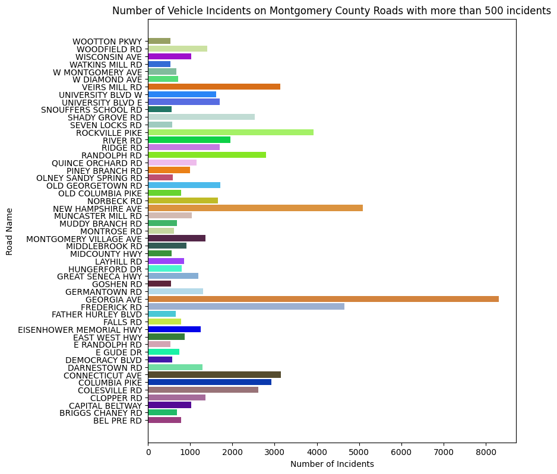

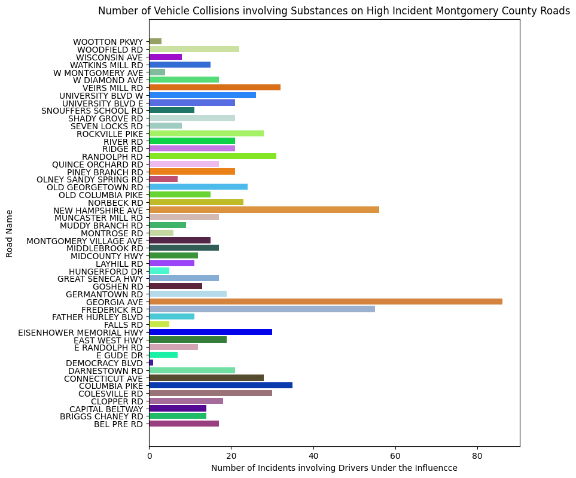

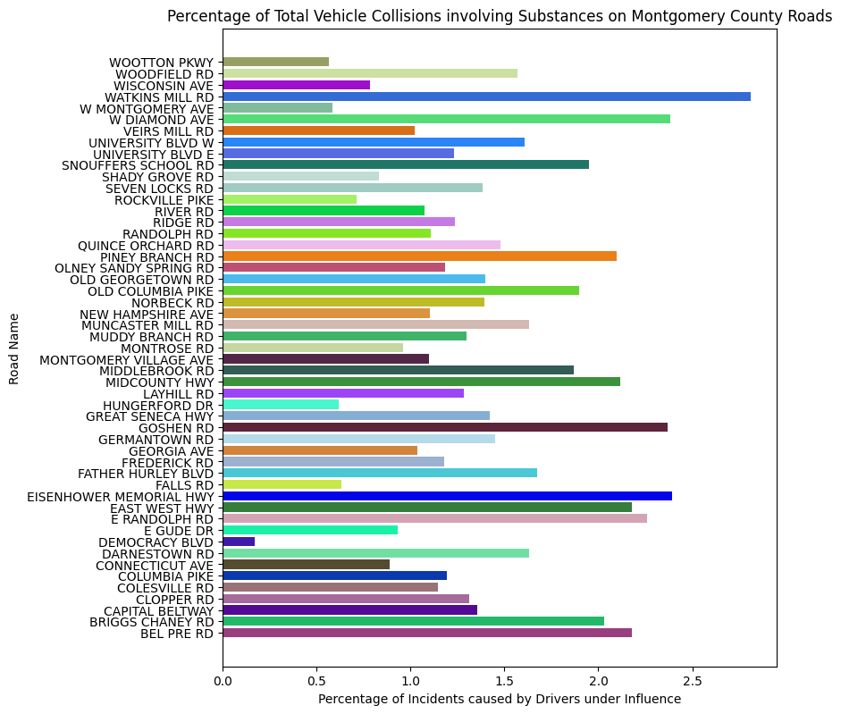

```python
# Constant for name spacing in graphs
bar_width_mod = 5.5
# Generate a list of n random colors
def nRandomColors(n):
    return list(tuple(np.random.random() for i in np.arange(3)) for j in np.arange(n))
# Find roads with at least inc_num incidents
# Minimum number of incidents
inc_num = 500
mostInc = data.value_counts(subset='Road Name', sort=False)
mostInc = mostInc[mostInc > inc_num]

# Plot data and format graph
plt.figure(figsize=(8, len(mostInc)/bar_width_mod))
colors = nRandomColors(len(mostInc))
plt.barh(y=mostInc.index, width=mostInc, color=colors)
plt.xlabel("Number of Incidents")
plt.ylabel("Road Name")
plt.title(f"Number of Vehicle Incidents on Montgomery County Roads with more than {inc_num} incidents")

# Determine how many events were under influence
influencedInc = data.value_counts(subset=['Road Name','underInfluence'], sort=False)
# Only use highest incident roads
influencedInc = influencedInc.loc[mostInc.index]
# Only count incidents of drunk driving
influencedInc = influencedInc.loc[:,True]

plt.figure(figsize=(8, len(influencedInc)/bar_width_mod))
plt.barh(y=influencedInc.index, width=influencedInc, color=colors)
plt.xlabel("Number of Incidents involving Drivers Under the Influencce")
plt.ylabel("Road Name")
plt.title(f"Number of Vehicle Collisions involving Substances on High Incident Montgomery County Roads")

# Now make a plot of percentage of the incidents involving substances
plt.figure(figsize=(8, len(influencedInc)/bar_width_mod))
plt.barh(y=mostInc.index, width=100*(influencedInc/mostInc), color=colors)
plt.xlabel("Percentage of Incidents caused by Drivers under Influence")
plt.ylabel("Road Name")
plt.title(f"Percentage of Total Vehicle Collisions involving Substances on Montgomery County Roads")
```

### Time of Incident

It's important to look at other factors that may be significant in prediction too, one of these factors being the time of the incident. There may be certain periods of time where incidents involving influenced drivers are more common. We'll try to predict times that will have a higher rate of it being caused by drivers under the influence.

> **Hypothesis**: *Incidences that occur between the times of* **`23:00`** *and* **`3:00`** *are more likely involve drivers under the influence.*

Using the exact time of the incident would be too specific, grouping the incidents into periods of time would offer better results. Thirty minute periods is likely the best choice since it will divide the data into 48 groups, which will be plotted against number of incidents involving influenced drivers, and percentage of all incidents during those time periods involving influenced drivers.

```python
# Create a column called 'timeGroup' which stores 30 minute time intervals
data['timeGroup'] = pd.to_datetime(data['Crash Date/Time']).dt.time
data['timeGroup'] = data['timeGroup'].apply(lambda x: str(dt.time(x.hour,30*int(x.minute/30),0)))
```

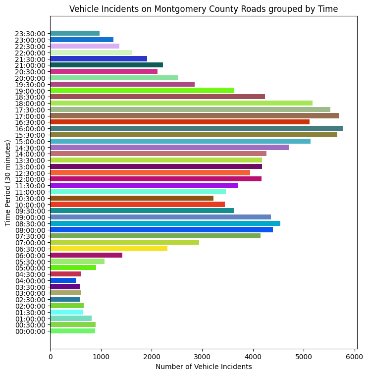

```python
# Organize frequency of arguments by time
incidentsByTime = data.value_counts(subset='timeGroup', sort=False, ascending=True)

# Plot incidents by time group
colors=nRandomColors(len(incidentsByTime))
plt.figure(figsize=(8, len(incidentsByTime)/bar_width_mod))
plt.barh(y=incidentsByTime.index,width=incidentsByTime,color=colors)
plt.xlabel("Number of Vehicle Incidents")
plt.ylabel("Time Period (30 minutes)")
plt.title("Vehicle Incidents on Montgomery County Roads grouped by Time")
```

From the graph, the trend on when the most accidents happen becomes clear. Peak traffic hours, aka rush hour, which is around **7:00 am** to **9:30 am** and **3:00 pm** to **7:00 pm** are when the most accidents happen. But that's not the information that we're seeking, we want to know more about when most accidents involving drivers under the influence happen.

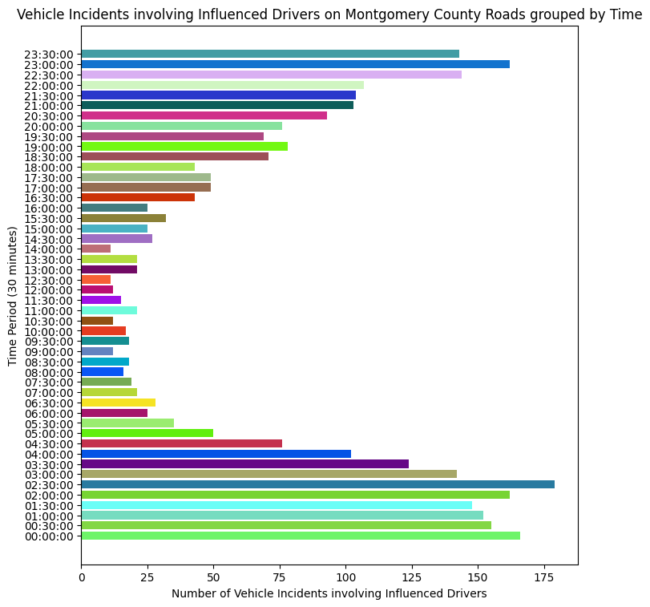

```python
# Organize by frequency of accidents by time period and group by under the influence
inflIncByTime = data.value_counts(subset=['timeGroup','underInfluence'], sort=False)
inflIncByTime = inflIncByTime[:,True]

# Plot incidents involving influenced drivers by time group
plt.figure(figsize=(8, len(inflIncByTime)/bar_width_mod))
plt.barh(y=inflIncByTime.index,width=inflIncByTime,color=colors)
plt.xlabel("Number of Vehicle Incidents involving Influenced Drivers")
plt.ylabel("Time Period (30 minutes)")
plt.title("Vehicle Incidents involving Influenced Drivers on Montgomery County Roads grouped by Time")
```

Looks like our **hypothesis was correct**, the time period with the highest number of influenced driving incidents is 2:30 am, and the most incidents seem to happen between our time interval of 11:00 pm to 3:00 am. We can find the proportion of these incidents as well:

```python
# Cast to np array
infl_inc_np = np.array(inflIncByTime)
print(f"{100*(infl_inc_np[-2:].sum()+infl_inc_np[:6].sum())/infl_inc_np.sum()}% of all influenced "
      + "driving incidents occur between 11:00 pm and 3:00 am")
```

```
39.20173267326733% of all influenced driving incidents occur between 11:00 pm and 3:00 am
```

Roughly 40% of all incidents involving an influenced driver the hours of `23:00` and `3:00` despite only making up 1/6 of the whole day. Let's make a graph that illustrates the percentage of incidents that are caused by drunk drivers at each time period.

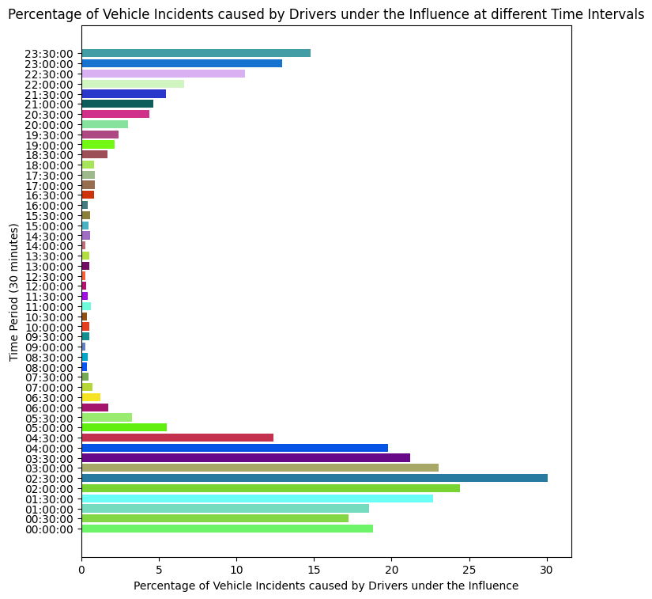

```python
# Plot percentage of incidents caused by drivers under the influence at each time period
plt.figure(figsize=(8, len(inflIncByTime)/bar_width_mod))
plt.barh(y=inflIncByTime.index,width=100*inflIncByTime/incidentsByTime,color=colors)
plt.xlabel("Percentage of Vehicle Incidents caused by Drivers under the Influence")
plt.ylabel("Time Period (30 minutes)")
plt.title("Percentage of Vehicle Incidents caused by Drivers under the Influence at different Time Intervals")
```

### Involved Vehicle Make and Year

One might think that make and year of the car might not really have anything to do with vehicle accidents. But consider the fact that as vehicles advance technologically and safety measures improve, it could prove to show that more recent years of cars, as well as more expensive brands might be involved in less accidents.

> **Hypothesis:** More recent car years and more expensive brand models are involved in less accidents, both involving drivers under the influence or not.

This may help with regression, as if there is a correlation between year and make of the car, and incident prevelance, this could be a good attribute to add to our model.

What range of years and makes are included in this data set?

```python
# Print the different makes and years that appear in the data set
print(data['Vehicle Make'].unique()[:40])
print(data['Vehicle Year'].unique()[:40])
```

```
['HONDA' 'UNK' 'FORD' 'TOYT' 'KENWORTH' 'VOLKSWAGEN' 'HYUN' 'MAZDA' 'GMC'
 'BMW' 'KIA' 'GILL' 'CHEVY' 'SUBA' 'VOLK' 'HOND' 'TOYOTA' 'HYUNDAI' 'PORS'
 'VOLKSWAGON' 'NISSAN' 'SUBARU' 'LEXUS' 'YAMAHA' 'PETERBUILT 389'
 'FREIGHT' 'INFI' 'RAM' 'TOYTA' 'CHEVROLET' 'ACUR' 'CHEV' 'CADILLAC'
 'GILG' 'JEEP' 'NISS' 'HARLEY DAVIDSON' 'VOLVO' 'DODG' 'GILLIG']
[2004    0 2003 2016 2001 2006 2014 2009 2000 2023 2005 2011 2019 2017
 2008 2013 2022 2012 2020 2015 2018 2007 2010 2021 1996 1999 1998 1997
 1991 2002 1995 9999 1992 2024 1900 1994 1985 1990   99 1993]
```

Unfortunately it seems that there is a lot of human error when these reports were made. There are many abbreviations and typos for the make of car in the dataset. Examples include *`HOND`* instead of *`HONDA`*, *`CHEVEROLET`* instead of *`CHEVROLET`*, *`TOYT`* instead of *`TOYOTA`*, and many more. Furthermore, there are also many incorrect years listed in the reports, such as the years 1, 2, 3, 4, 999, 1234, 2048, 2911, 8008, 9999.

To fix this, we're going to perform some more data cleaning and curation. We will view the most frequently reported vehicle makes and map any abbreviations or misspellings to its full actual name (like *`HOND`* to *`HONDA`*). For the incorrect years, we will replace any vehicle year that is unreasonable with `NaN`.

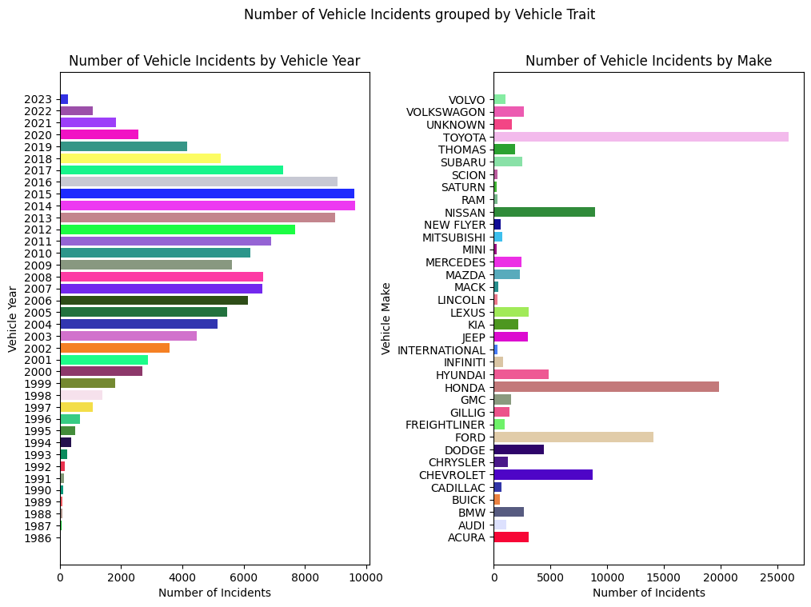

```python
# --- Clean Data --
# - Clean Vehicle Year column
lowerYear, upperYear = 1900, 2023
data['Vehicle Year'] = data['Vehicle Year'].apply(lambda x: np.nan if x < lowerYear or x > upperYear else x)

# - Clean Vehicle Make column
# We get these values by looking through all the unique values in the vehicle make column
# in the commented line above
# Map abbreviations/typos to actual model name :
vehicleMakeMapping = {"ACUR":"ACURA", "CADI":"CADILLAC","CHEV":"CHEVROLET", "CHEVY":"CHEVROLET",
"CHRY":"CHRYSLER","DODG":"DODGE", "FRHT":"FREIGHTLINER", "GILL":"GILLIG", "HOND":"HONDA",
"HYUN":"HYUNDAI","INFI":"INFINITI", "LEXS":"LEXUS", "LEXU":"LEXUS", "MAZD":"MAZDA",
"MITS":"MITSUBISHI","MERZ":"MERCEDES", "NISS":"NISSAN", "SUBA":"SUBARU", "THOM":"THOMAS",
"TOYT":"TOYOTA", "VOLK":"VOLKSWAGON", "VOLKS":"VOLKSWAGON", "VW":"VOLKSWAGON", "VOLKSWAGEN":"VOLKSWAGON",
"VOLV":"VOLVO",}

# Apply abbreivation mapping dictionary
def applyMapping(x):
    try:
        return vehicleMakeMapping[x]
    except KeyError:
        return x
data['Vehicle Make'] = data['Vehicle Make'].apply(lambda x: applyMapping(x))

# --- Organize Data ---
# Collect and organize most frequent vehicle years
incidentsByYear = data['Vehicle Year'].value_counts(sort=False)
incidentsByYear= incidentsByYear[incidentsByYear >= 35]
# Collect and organize most frequent vehicle models in the data
incidentsByMake = data['Vehicle Make'].value_counts(sort=False)
incidentsByMake = incidentsByMake[incidentsByMake > 250].sort_index()

# --- Plot Data ---

yearColor = nRandomColors(len(incidentsByYear))
makeColor = nRandomColors(len(incidentsByMake))

fig, (ax1, ax2) = plt.subplots(1, 2, figsize=(12,8))
plt.subplots_adjust(wspace=0.4)
plt.suptitle("Number of Vehicle Incidents grouped by Vehicle Trait")

ax1.barh(y=incidentsByYear.index,width=incidentsByYear,color=yearColor)
ax1.set_yticks(incidentsByYear.index)
ax1.set_xlabel("Number of Incidents")
ax1.set_ylabel("Vehicle Year")
ax1.set_title("Number of Vehicle Incidents by Vehicle Year")

ax2.barh(y=incidentsByMake.index,width=incidentsByMake,color=makeColor)
ax2.set_xlabel("Number of Incidents")
ax2.set_ylabel("Vehicle Make")
ax2.set_title("Number of Vehicle Incidents by Make")
```

- Though this graph may give us some good information, you can't draw conclusions about the rate of accidents per vehicle year and make.
- Even though Toyotas, Fords, and Hondas have the most number of incidents, that's not because those specific makes are more likely to get into incidents, but rather there are more of them on the road, so they just happened to be involved in more incidents because of their frequency. Similarly, Saturns and Mini Coopers have very few incidents, not because driving one of these brands means you're less likely to get into an accident, but rather there are less of them on the road.
- This is the same for vehicle year as well. Simply because vehicles of years 2013-2016 are involved in more accidents does not mean those types of cars are more likely to get into accidents, but because there are more of them in the road.
- Unfortunately since this dataset only provides information on incidents rather than total number of cars on the road, it's hard to say for sure from this data the rate of accidents per brand since that would require dividing the number of incidents involving *make 'x'* by total number of *make 'x'*, and same goes for vehicle year, and this is all information that is not provided by the dataset we're using.
- However, this data is still useful because it's possible to view the rate of incidents involving drivers under the influence for each vehicle year and make. This requires dividing the number of incidents for *make 'x'/vehicle year 'y'* involving inebriated drivers by the total number of accidents for *make 'x'/vehicle year 'y'.*

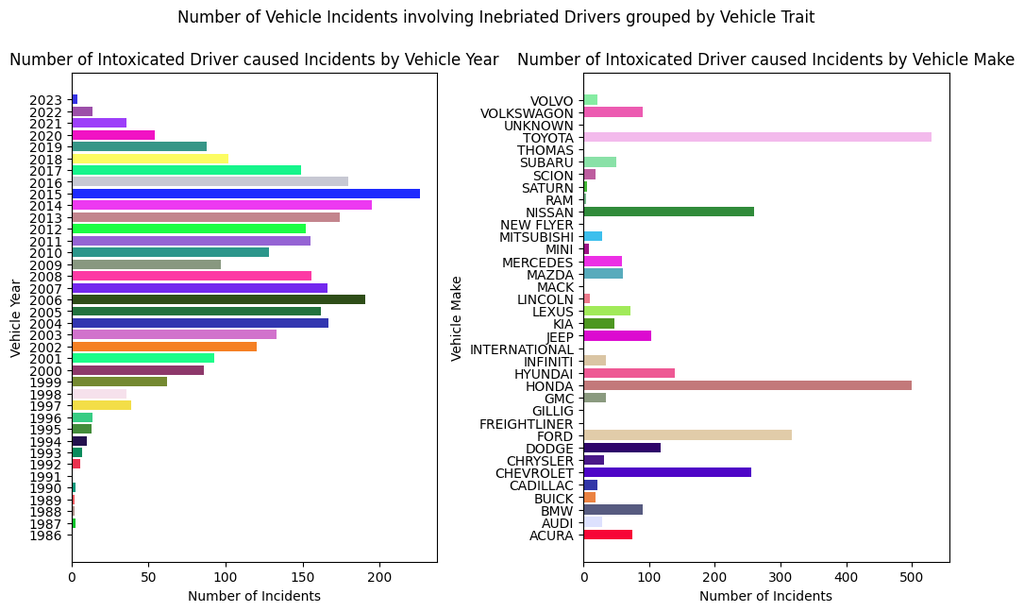

```python
# Organize data by vehicle year and under the influence
inflAccByYear = data[['Vehicle Year','underInfluence']].value_counts(sort=False)
inflAccByYear = inflAccByYear.loc[incidentsByYear.index]
inflAccByYear = inflAccByYear.loc[:, True]

# Organize by vehicle make and under the unfluence
inflAccByMake = data[['Vehicle Make','underInfluence']].value_counts(sort=False)
inflAccByMake = inflAccByMake.loc[incidentsByMake.index]
# Value counts doesn't count categories with no frequency, so we must insert them manually
noAccidents = np.setdiff1d(np.array(inflAccByMake.loc[:, False].index),np.array(inflAccByMake.loc[:, True].index))
for make in noAccidents:
    inflAccByMake[(make, True)] = 0
inflAccByMake = inflAccByMake.loc[:, True].sort_index()

# Plot accidents involving inebriated drivers that occur by year and make

fig_height = (len(inflAccByYear) + len(inflAccByMake)) / (2 * bar_width_mod)
fig, (ax1, ax2) = plt.subplots(1, 2, figsize=(12,fig_height))
plt.subplots_adjust(wspace=0.4)
plt.suptitle("Number of Vehicle Incidents involving Inebriated Drivers grouped by Vehicle Trait")

ax1.barh(y=inflAccByYear.index,width=inflAccByYear,color=yearColor)
ax1.set_yticks(inflAccByYear.index)
ax1.set_xlabel("Number of Incidents")
ax1.set_ylabel("Vehicle Year")
ax1.set_title("Number of Intoxicated Driver caused Incidents by Vehicle Year")

ax2.barh(y=inflAccByMake.index,width=inflAccByMake,color=makeColor)
ax2.set_xlabel("Number of Incidents")
ax2.set_ylabel("Vehicle Make")
ax2.set_title("Number of Intoxicated Driver caused Incidents by Vehicle Make")
```

Again, this doesn't provide a lot of information because there are going to be more accidents involving more frequently used cars regardless of the drivers inebriation status. To actually get some substantial information, we'll calculate the rate of drunk driving incidents per each trait. Doing this will provide information on how many of the incidents caused by a certain year/make also happen to be intoxicated driver accidents, which will illustrate if a certain brand or year is more likely to be involved in these type of accidents.

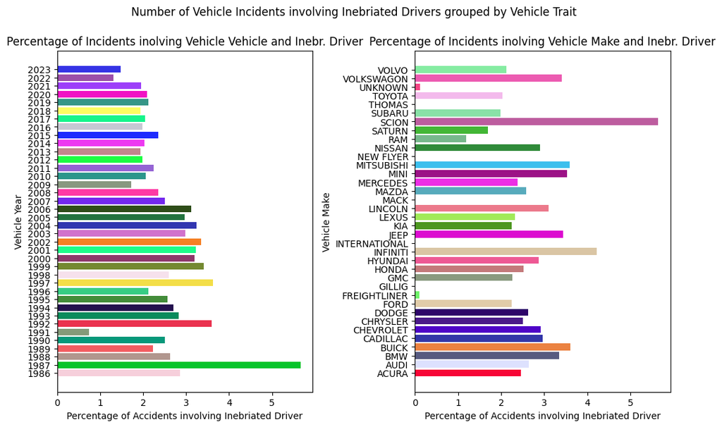

```python
# Plot percentage of accidents involving inebriated drivers that occur by year and make

fig_height = (len(inflAccByYear) + len(inflAccByMake)) / (2 * bar_width_mod)
fig, (ax1, ax2) = plt.subplots(1, 2, figsize=(12,fig_height))
plt.subplots_adjust(wspace=0.4)
plt.suptitle("Number of Vehicle Incidents involving Inebriated Drivers grouped by Vehicle Trait")

ax1.barh(y=inflAccByYear.index,width=100*inflAccByYear/incidentsByYear,color=yearColor)
ax1.set_yticks(inflAccByYear.index)
ax1.set_xlabel("Percentage of Accidents involving Inebriated Driver")
ax1.set_ylabel("Vehicle Year")
ax1.set_title("Percentage of Incidents inolving Vehicle Vehicle and Inebr. Driver")

ax2.barh(y=inflAccByMake.index,width=100*inflAccByMake/incidentsByMake,color=makeColor)
ax2.set_xlabel("Percentage of Accidents involving Inebriated Driver")
ax2.set_ylabel("Vehicle Make")
ax2.set_title("Percentage of Incidents inolving Vehicle Make and Inebr. Driver")
```

This is information that can be used. It seems like portions of our hypothesis were correct while other portions were not. If an older year vehicle gets into an accident, it's more likely that they'll be inebriated than if a newer model gets into one, which is correspondant with our hypothesis. However, it seems unclear if drivers of more expensive makes of cars tend to be more inebriated when getting into an accident than drivers of more affordable makes. Drivers of car brands like Honda, Mercedes, Lexus are less likely to be be intoxicated when involved in an accident, while drivers of car brands lsike Infiniti, Mini Coopers, Mistubishis are more likely to be inebriated when getting into an accident.

Note that there are some small sample sizes that may not reflect the true likelihood of inebriation. For example, drivers of 1987 cars and Scions have a much higher chance of being inebriated when involved in a crash according to the data. But this is more likely a result of small sample sizes rather than actual trends. There aren't many 1987 cars or Scions on the road, and the fact that they've had more accidents involving substances might just be by chance instead of actually having a higher rate.

Nonetheless, this data provides useful information, and the regression analysis can use this attribute in calculating the probably that a driver in an incident is inebriated.

### Intersection of Incident

We're interested in seeing whether the crash occurred at an intersection, and what type of intersection, has any correlation with the driver being under the influence or not. There are three columns for interesection data: `Junction`, `Intersection Type`, and `Intersection Area`, which we will want to aggregate into a single column for ease of access. We're concerned with whether it occurred at an intersection or not, and if it did, what kind of intersection? The different types of intersections in `Intersection Type` are `T-INTERSECTION`, `Y-INTERSECTION`, `FOUR-WAY INTERSECTION`, `FIVE-POINT OR MORE`, `ROUNDABOUT`, `TRAFFIC CIRCLE`, and `OTHER`.

> **Hypothesis:** Four way intersections, roundabouts, and traffic circles will have the highest rates of incidents being due to an intoxicated driver being unable to react in time to signals and oncoming traffic at this types of junctions.

```python
non_intersection = 'NON INTERSECTION'
intersections = np.array(['INTERSECTION', 'INTERSECTION RELATED', 'INTERCHANGE RELATED', 'CROSSOVER RELATED', 'OTHER'])

# --- Data Cleaning ---
def getCleanIntersection(incident):
    if incident['Junction'] in intersections:
        return incident['Intersection Type']
    else:
        return non_intersection

# Fill nonfilled data with not intersection or other
data[data['Junction'] == np.nan] = non_intersection
data[data['Intersection Type'] == 'UNKNOWN'] = 'OTHER'
# Create new column
data['intersection'] = data.apply(getCleanIntersection, axis=1)
# Drop old data
data.drop(columns=['Junction', 'Intersection Type', 'Intersection Area'], inplace=True)
```

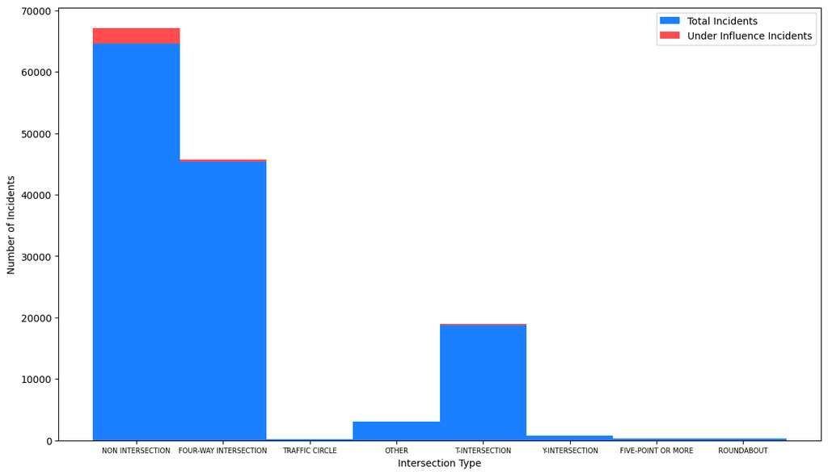

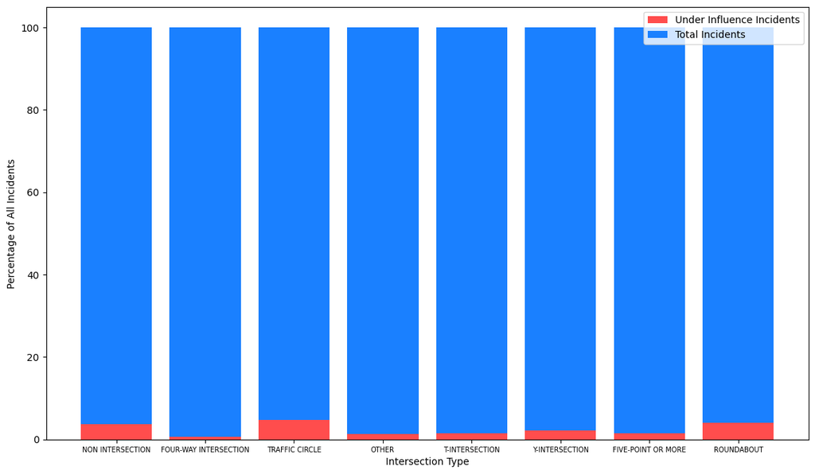

```python
# --- Data Organization and Collection---
intersAcc = data['intersection'].value_counts(sort=False)
intersAccInfl = data[['intersection','underInfluence']].value_counts(sort=False)
intersAccInfl = intersAccInfl[:,True]

# Plot number of total accidents and number of inebriated accidents
normalColor = (0.1, 0.5, 1.0)
influenceColor = (1.0, 0.3, 0.3)

fig, ax = plt.subplots(figsize=(14,8))

for intersec in intersAcc.index:
    val = intersAcc[intersec]-intersAccInfl[intersec]
    ax.bar(intersec, val, width=1.0, color=normalColor)
    ax.bar(intersec, intersAccInfl[intersec], width=1.0, color=influenceColor, bottom=val)

ax.set_xticklabels(intersAcc.index, fontsize=7)
plt.xlabel("Intersection Type")
plt.ylabel("Number of Incidents")
ax.legend(["Total Incidents", "Under Influence Incidents"])
plt.show()

# Plot the percentage of accidents at intersection involving inebriated drivers
fig, ax = plt.subplots(figsize=(14,8))

for intersec in intersAcc.index:
    val = 100*intersAccInfl[intersec]/intersAcc[intersec]
    ax.bar(intersec, val, color=influenceColor)
    ax.bar(intersec, 100-val, color=normalColor, bottom=val)

ax.set_xticklabels(intersAcc.index, fontsize=7)
plt.xlabel("Intersection Type")
plt.ylabel("Percentage of All Incidents")
ax.legend(["Under Influence Incidents", "Total Incidents"])
plt.show()
```

There are many other aspects that we can consider important, however, since there around 50 attributes, we won't explore all of them for the sake of being concise and efficient. The ones that we explored are important factors that can be significant when performing the regression analysis, but there will also be other minor factors that will be included in the analysis, but that we didn't cover in this section.

## **Part 3: Regression Analysis and Prediction**

Now that we've compiled a few key attributes, it's time to perform regression analysis. Regression analysis is a method that is used by statisticians to represent a relationship between a dependent variable, and one or more independent variables. Whereas statiscians use them for creating lines of best fit, data analyists use regression learning for predicting future trends and values of data features, and classifying an observation based on it's attributes.

Typically, regression analysis would be created and tested with training data and test data, respectively. However, since we only have training data, we'll perform a technique called **K-Fold Cross Validation**, which divides our training data into two subsets: **training data** and **validation data**, where we use the validation data to test our models accuracy (test data). The size of the validation data is the total data divided by **k**, which is a value that we specify. Any data that is not part of validation data is training data.

We'll be using the `sklearn.logistic_regression` library to perform logistic regression for us. We'll need to compile a list of the variables we want to consider when performing regression. It will observe trends and correlations between a drivers sobriety and other factors. However, `sklearn` requires that all variables are numbers, and since our dataset consists mostly of strings, we'll have to convert them into numbers using `sklearn`'s `LabelEncoder`.

```python
# List of important attributes, not including identifiers like report number and
# vehicle ID
attributesFull = ['Agency Name', 'ACRS Report Type', 'Route Type', 'Road Name',
'Municipality', 'Related Non-Motorist', 'Collision Type', 'Weather', 'Surface Condition',
'Light', 'Traffic Control', 'Driver Substance Abuse', 'Non-Motorist Substance Abuse',
'Driver At Fault', 'Injury Severity', 'Circumstance', 'Driver Distracted By',
'Drivers License State', 'Vehicle Damage Extent', 'Vehicle First Impact Location',
'Vehicle Second Impact Location', 'Vehicle Body Type', 'Vehicle Movement',
'Speed Limit', 'Parked Vehicle', 'Vehicle Year', 'Vehicle Make', 'Vehicle Model',
'Equipment Problems', 'Hit/Run', 'Lane Type', 'Number of Lanes', 'Road Grade',
'NonTraffic', 'First Harmful Event', 'Second Harmful Event', 'Fixed Oject Struck',
'Road Alignment', 'Road Condition', 'Road Division', 'timeGroup', 'underInfluence',
'intersection']
```

```python
# Make a copy of our data and shuffle
testing_data = data.copy()[attributesFull].sample(frac=1)
testing_data.reset_index(drop=True, inplace=True)

# Convert underInfluence bool column to be represented in 0s and 1s
boolInfluenced = pd.Series(np.array(testing_data['underInfluence']).astype(bool))
testing_data['underInfluence'] = boolInfluenced.apply((lambda x: 1 if x==True else 0))

# Function to encode nominal values to numeric values
def encodeData(input_data):
    # Init encoder
    encoder = sk.preprocessing.LabelEncoder()
    for col in np.array(input_data.columns):
        if col == 'underInfluence': continue
        # Convert non-string data in training data to string data (required by encoder)
        input_data.loc[:,col] = np.array(input_data[col]).astype(str)
        # Encode data to numeral
        input_data.loc[:,col] = encoder.fit_transform(input_data[col])
    return input_data

# Perform k-folds
def kFoldsTesting(k, formula, test_data):

    # Data slices we'll use
    folds = np.linspace(0, len(test_data.index), k+1).astype(int)

    # Make the model
    log_reg_sk = LogisticRegression(max_iter=1500)
    iter = 0
    scores = []
    for i in range(k):
        # Data organization
        val_data = test_data[folds[i]:folds[i+1]]
        training_data = pd.concat([test_data[0:folds[i]],test_data[folds[i+1]:len(data.index)]])

        # Model creation and testing
        wrn.filterwarnings("ignore") # Ignore max iteration warnings
        log_reg_sk.fit(training_data.drop(columns=['underInfluence']),training_data['underInfluence'])
        score = log_reg_sk.score(val_data.drop(columns=['underInfluence']), val_data['underInfluence'])
        scores.append(score)
        #print(f"Score for iteration {iter} is {score}")
        iter += 1
    print(f" * Prediction Scores for k={k}: {scores}")
    print(f" * Average accuracy for this run across all tests: {np.mean(scores) * 100}%")
    return np.mean(scores)

k = 10
total_score = 0
data_step_size = 7500
steps = list(np.arange(0, len(testing_data.index), 10000))
# Run scores
for data_step in steps:
    # Print current step
    next_step = data_step + (data_step_size - 1)
    next_step = next_step if next_step < len(testing_data.index) else len(testing_data.index)
    print("Running K-Folds Cross Validation with Logistic Regression Model"
    + f" for observations {data_step} to {next_step}")

    # Get test data, make sure to encode data
    test_data = encodeData(testing_data[data_step:next_step])
    total_score += kFoldsTesting(k, "", test_data)
print(f"Average score for this Logistic Regression Model across all data: {total_score/len(steps)}")
```

```
Running K-Folds Cross Validation with Logistic Regression Model for observations 0 to 7499
 * Prediction Scores for k=10: [0.9973297730307076, 0.9973333333333333, 0.9986666666666667, 0.9986666666666667, 0.9986666666666667, 0.9986666666666667, 0.996, 1.0, 1.0, 0.996]
 * Average accuracy for this run across all tests: 99.81329773030707%
Running K-Folds Cross Validation with Logistic Regression Model for observations 10000 to 17499
 * Prediction Scores for k=10: [0.9986648865153538, 1.0, 0.9973333333333333, 0.996, 1.0, 0.9986666666666667, 1.0, 1.0, 0.9973333333333333, 0.9973333333333333]
 * Average accuracy for this run across all tests: 99.85331553182021%
Running K-Folds Cross Validation with Logistic Regression Model for observations 20000 to 27499
 * Prediction Scores for k=10: [0.9973297730307076, 0.9986666666666667, 1.0, 1.0, 1.0, 1.0, 1.0, 1.0, 1.0, 0.9973333333333333]
 * Average accuracy for this run across all tests: 99.93329773030709%
Running K-Folds Cross Validation with Logistic Regression Model for observations 30000 to 37499
 * Prediction Scores for k=10: [0.9986648865153538, 0.9973333333333333, 0.9986666666666667, 1.0, 0.9986666666666667, 0.9973333333333333, 1.0, 0.996, 0.9986666666666667, 0.9973333333333333]
 * Average accuracy for this run across all tests: 99.82664886515353%
Running K-Folds Cross Validation with Logistic Regression Model for observations 40000 to 47499
 * Prediction Scores for k=10: [1.0, 1.0, 0.9986666666666667, 1.0, 1.0, 1.0, 0.9986666666666667, 1.0, 1.0, 0.9973333333333333]
 * Average accuracy for this run across all tests: 99.94666666666667%
Running K-Folds Cross Validation with Logistic Regression Model for observations 50000 to 57499
 * Prediction Scores for k=10: [1.0, 0.9986666666666667, 0.996, 1.0, 1.0, 0.9986666666666667, 1.0, 1.0, 0.9986666666666667, 1.0]
 * Average accuracy for this run across all tests: 99.92000000000002%
Running K-Folds Cross Validation with Logistic Regression Model for observations 60000 to 67499
 * Prediction Scores for k=10: [0.9973297730307076, 0.9986666666666667, 0.9986666666666667, 0.9986666666666667, 0.9986666666666667, 0.9973333333333333, 0.9986666666666667, 0.9973333333333333, 0.9986666666666667, 1.0]
 * Average accuracy for this run across all tests: 99.83996439697374%
Running K-Folds Cross Validation with Logistic Regression Model for observations 70000 to 77499
 * Prediction Scores for k=10: [0.9973297730307076, 0.9986666666666667, 0.9973333333333333, 0.9986666666666667, 0.9986666666666667, 0.9986666666666667, 1.0, 0.9973333333333333, 0.996, 0.9946666666666667]
 * Average accuracy for this run across all tests: 99.77329773030709%
Running K-Folds Cross Validation with Logistic Regression Model for observations 80000 to 87499
 * Prediction Scores for k=10: [1.0, 1.0, 0.9986666666666667, 0.9986666666666667, 0.9986666666666667, 0.9986666666666667, 0.9986666666666667, 0.9986666666666667, 0.9986666666666667, 0.9986666666666667]
 * Average accuracy for this run across all tests: 99.89333333333335%
Running K-Folds Cross Validation with Logistic Regression Model for observations 90000 to 97499
 * Prediction Scores for k=10: [0.9986648865153538, 0.9986666666666667, 1.0, 1.0, 1.0, 1.0, 0.996, 0.9973333333333333, 1.0, 0.9986666666666667]
 * Average accuracy for this run across all tests: 99.89331553182022%
Running K-Folds Cross Validation with Logistic Regression Model for observations 100000 to 107499
 * Prediction Scores for k=10: [0.9986648865153538, 0.9986666666666667, 1.0, 1.0, 1.0, 1.0, 1.0, 0.9986666666666667, 1.0, 0.996]
 * Average accuracy for this run across all tests: 99.91998219848688%
Running K-Folds Cross Validation with Logistic Regression Model for observations 110000 to 117499
 * Prediction Scores for k=10: [0.9973297730307076, 0.9986666666666667, 0.9986666666666667, 0.9986666666666667, 1.0, 0.9986666666666667, 0.9986666666666667, 0.996, 1.0, 1.0]
 * Average accuracy for this run across all tests: 99.86663106364041%
Running K-Folds Cross Validation with Logistic Regression Model for observations 120000 to 127499
 * Prediction Scores for k=10: [0.9973297730307076, 0.9986666666666667, 1.0, 1.0, 0.9986666666666667, 0.9946666666666667, 1.0, 1.0, 1.0, 1.0]
 * Average accuracy for this run across all tests: 99.89329773030707%
Running K-Folds Cross Validation with Logistic Regression Model for observations 130000 to 137499
 * Prediction Scores for k=10: [0.9986648865153538, 1.0, 0.9973333333333333, 1.0, 0.9986666666666667, 1.0, 0.9986666666666667, 0.9986666666666667, 1.0, 0.996]
 * Average accuracy for this run across all tests: 99.87998219848689%
Average score for this Logistic Regression Model across all data: 0.9987521647911501
```

Looks like our logistic regression is very successful, when given information about a vehicle incident, it's able to predict if the accident involved a driver under the influence with greater than 98% accuracy.

## **Final Section**

### Discussion

Though the model is highly accurate, this model is not designed to determine a drivers sobriety in the real world. It should not be used to accuse a driver in real-world circumstances where their sobriety is inconclusive/not-measured, but rather could be used as a tool with high scrutiny by the user, more to gather information before arriving to an incident or doing research. There have been many cases in the past in which a machine learning algorithm trained on collected data will reflect the biases that were contained within the data. This can lead to false positives when examining an observation with specific attribute values, and can cause major problems if prediction by the model is the only factor considered.

Furthermore, the data and conclusions drawn within this project may not reflect the dangers of the roads and incident rates of other Maryland counties, other states, or other countries. It is only generalizable for Montgomery County, Maryland, and even then, the used data only goes back to 2015, has many typos and errors contained within reports that need to be cleaned, and is still being collected and managed weekly by Montomgery County.

### Conclusion

There are many ways that a driver can be considered under the influence. They could be intoxicated through the use of alcohol, have one or more illegal drugs tested in their system, or have taken medicine that impairs the senses and reflexes. The data collected, cleaned, and illustrated in this project have shown the chances of a driver being inebriated given incident data like road, incident time, vehicle make and year. Using all the attributes of an incident from our dataset, we've trained a machine learning model that can predict whether or not an accident involved a driver under the influence. Though accurate, the model is only meant for research purposes and is not designed to count as evidence against a driver in an incident, as there are many examples of trained models inaccurately predicting information as a person. It's the job of data analysts and machine learning professionals to account for bias in training data as well as their models, and to not draw any concrete conclusions based on the results of their models.

### Special Thanks

Thank you to openMontgomery by Montgomery County for providing the data used in this project. Additionally, thank you to Professor Teli and the TA staff helping to run CMSC320 for a great semester.

Joseph Penovich - August 20th, 2023